# Summary of sediment-storm relationship

Lindsay R.C. Platt

2023-08-22

## Background

We hypothesize that more frequent, high intensity storms are contributing to the increases in algal blooms in western arm of Lake Superior. Following the remotely sensed sediment classification workflow, we set out to start exploring the relationship between sediment presence with conditions in the contributing basins.

[This issue on GitHub](https://github.com/LimnoDataScience/plume_bloom_drivers/issues/11) chronologically captures my exploration process. However, I am summarizing our current findings and next steps in this document. The code captured here assumes that you have run the pipeline and have created the targets referenced in `tar_read()` or `tar_load()` commands.

## Area of interest

We chose four 10-digit Hydrologic Unit Codes (HUC10) in the Lake Superior watershed with a USGS National Water Information System (NWIS) stream gage. The approach for downloading and processing the climate driver and discharge data is currently automated. Adding a new basin in the future would be easy; we only need to manually identify the NWIS stream gage associated with it. Below is a map of the four basins and their NWIS stream gages (not all gages are located at the outlet of the basin into Lake Superior, some are further upstream).

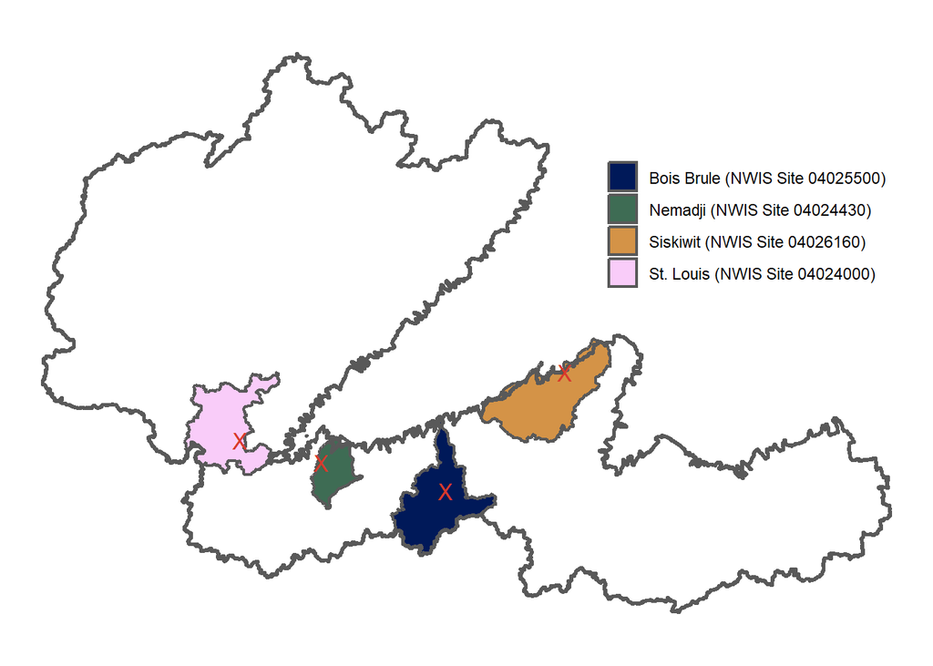

## Visualizing data

### Sediment presence

The main data input is our sediment presence data. I started with the tabular output available from the [Superior-Plume-Bloom classification workflow](https://github.com/rossyndicate/Superior-Plume-Bloom). These tabular data report sediment percentages for the full Lake Superior AOI per satellite date. There is no spatial information associated with them, and I filtered to only those mission-dates where at least 50% of the AOI was able to be classified. There are now exported rasters of the classified output, but I have yet to explore them in this analysis. I will be moving onto that next; see Next Steps.

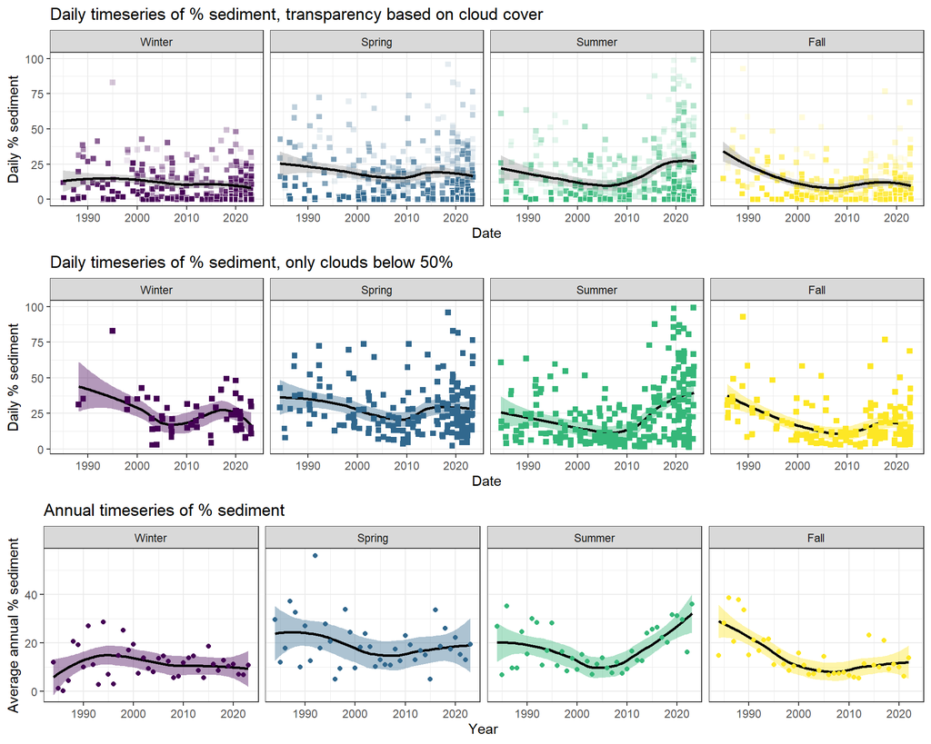

### Precipitation

Precipitation data was downloaded from PRISM and summarized into daily totals per basin for each of the four basins (more about that process is documented in [this pull request](https://github.com/LimnoDataScience/plume_bloom_drivers/pull/8)). You’ll notice a slight dip in the precip totals between 2000-2010. This happens around the same time as a dip in the sediment timeseries (see the sediment figure).

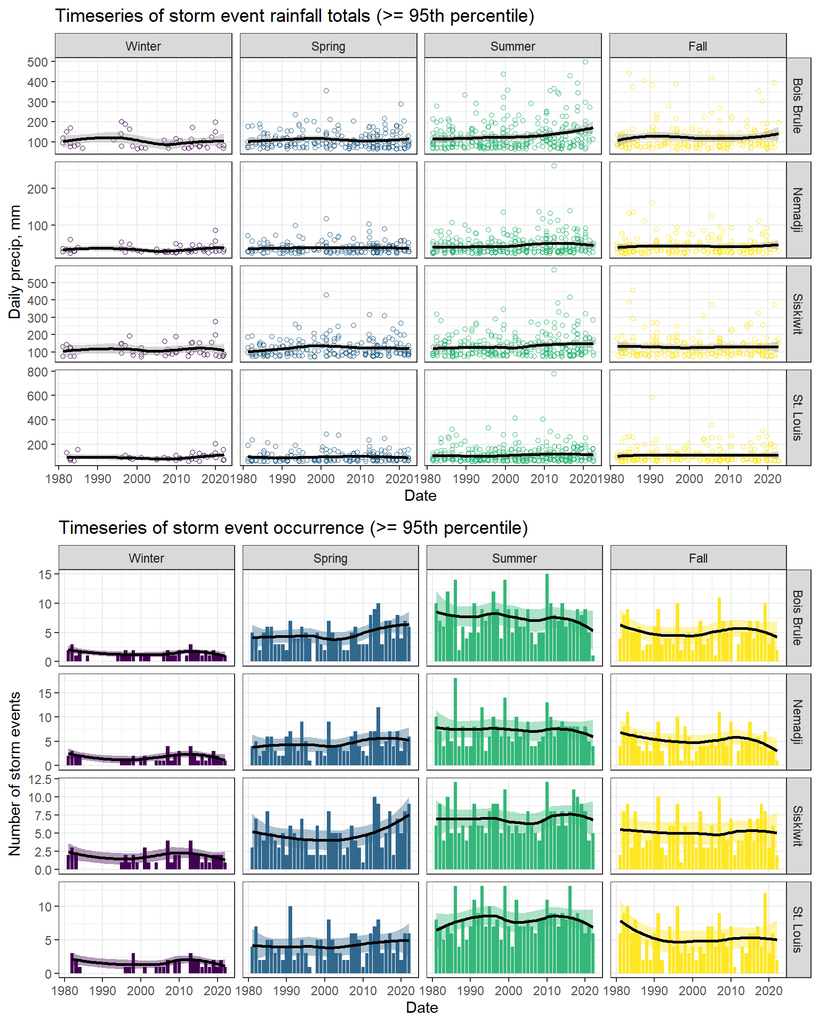

### NWIS discharge

Discharge was downloaded using `dataRetrieval`. Daily mean values are visualized below for each of the four NWIS sites identified. Note that the Siskiwit site is a newer site and has fewer data points. As such, it may be difficult to draw conclusions about a sediment-discharge relationship for this basin in future analyses.

Similar to the sediment and precip, we see a slight dip between 2000-2010. Interesting …

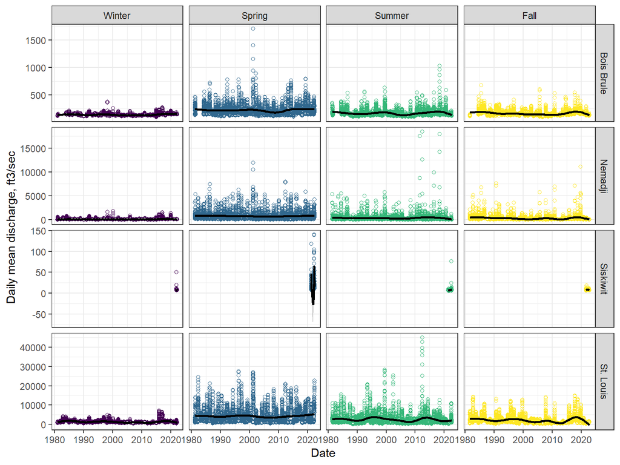

## Building relationships

### Precip-Q

I took some time to evaluate the relationship between our weighted cumulative precip data and the discharge reported at each basin. The initial relationships were not encouraging, so we tried a few different things:

1. accounting for basin shape/size and gage placement using a lag,
2. separating out the seasons, and
3. filtering to only storm days.

A lag between discharge and precipitation for each basin was determined by using a cross correlation function and identifying the maximum correlation for each basin. This plot shows differences in how the discharge and precipitation are correlated for each basin.

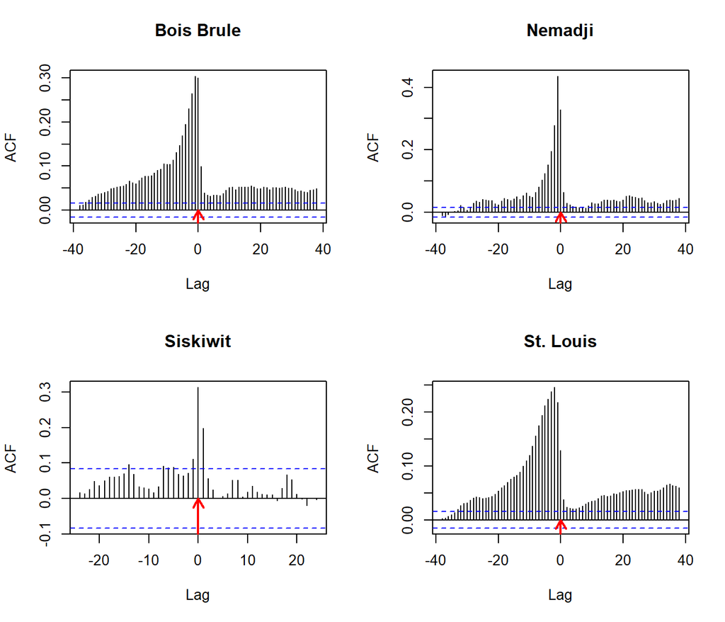

Both by actual date and by using each of the individual basin lags, precipitation was matched to discharge values. All four panels show the relationship between discharge vs precipitation. It mostly makes sense but might not be as close to a 1:1 as I thought it would be. Note that you will not see a difference for Siskiwit when lag is added because the lag found from cross correlation was 0 days.

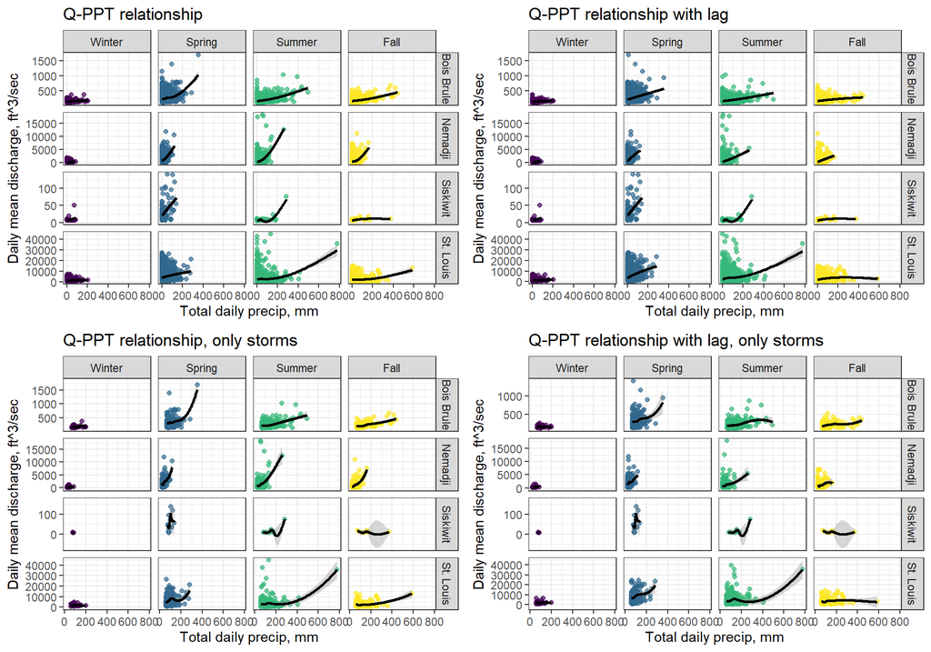

### Precip-sediment

Our initial hypothesis was the more intense rainfall events have led to the increased algal blooms. To start to understand whether this could be true, I looked at the relationship between precipitation and sediment presence. I filtered the dataset to only those mission-dates around an observed bloom event. The precipitation was totaled per basin for 7-day ahead cumulative precipitation values using only those days that experienced “storm” (greater than the 95th percentile) precipitation. Since we have not started to use the rasterized output data for sediment, each of the relationships are using the same sediment data - daily percent of sediment in the entire classifiable AOI without shoreline contamination. For each bloom date, I calculated the sediment presence as the maximum sediment percentage using daily values from 7 days ahead PLUS 3 days after the bloom date.

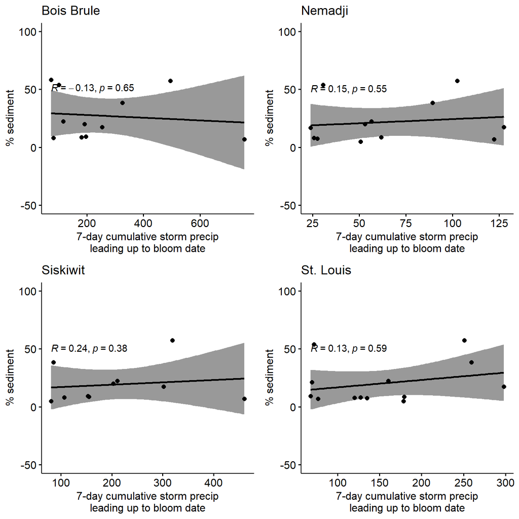

### Q-sediment

Since the precip-sediment relationships were not as strong as I thought they would be, I also tried looking at discharge-sediment. These are still not very strong, though Bois Brule looks more promising, so I think trying them again but using only sediment in areas that are near the river outlets (see Next Steps) might strengthen this relationship.

For each bloom event, I calculated a matching discharge by finding the maximum discharge over the previous 7 days.

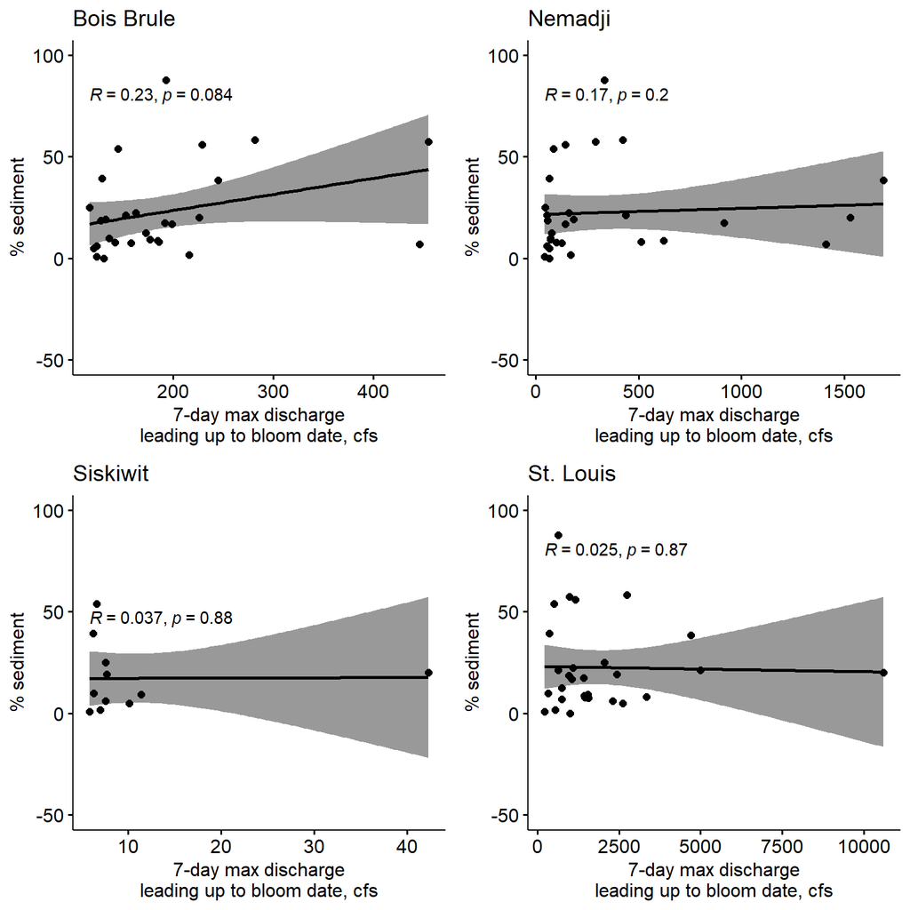

## Next steps

At this time, I only have two ideas of what to try next. I will be interested in connecting about where we can go next with this.

1. Use [the raster sediment presence output](https://www.hydroshare.org/resource/17cd38e9ac7845c29b0f45dab15e7073/) (maybe automate the download with [this tool](https://castronova.github.io/hstools/getting-started/)) to rebuild precip-sediment and Q-sediment relationships by grouping raster cells that are near each of the basin outlets.
2. Try the discharge-sediment relationship again but use custom windows based on the identified basin lag from the cross correlation function to set the window for finding maximum discharge ahead of a bloom event.